# PALMO (Platform for Analyzing Longitudinal Multi-omics data)

Suhas Vasaikar, PhD

Last compiled on 17 August, 2022

```r
library(PALMO)
```

# Introduction

PALMO `(Platform for Analyzing Longitudinal Multi-omics data)` is a platform for anayzing longitudinal data from bulk as well as single cell. It allows to identify inter-, intra-donor variations in genes over longitudinal time points. The analysis can be done on bulk expression dataset without known celltype information or single cell with celltype/user-defined groups. It allows to infer stable and variable features in given donor and each celltype (or user defined group). The outlier analysis can be performed to identify technical/biological perturbed samples in donor/participant. Further, differential analysis can be performed to decipher time-wise changes in gene expression in a celltype.

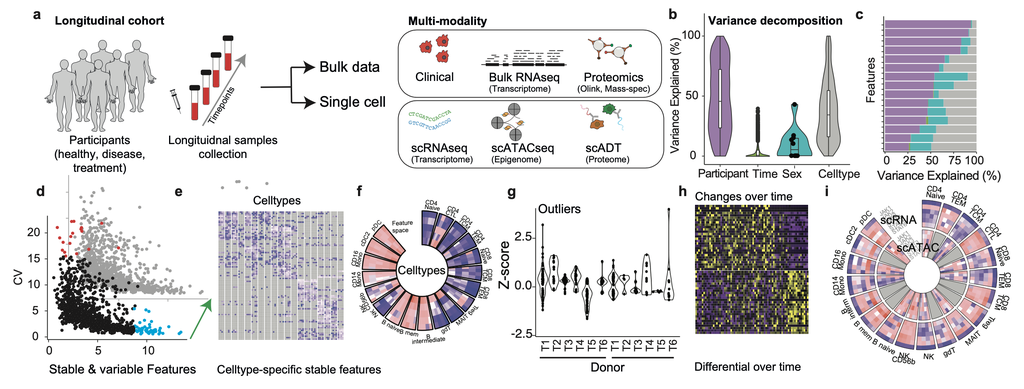

General workflow and analysis schema of **PALMO**. It can work with longitudinal data obtained from bulk such as clinical, bulk RNAseq, proteomic or single cell dataset from scRNAseq, and scATACseq.

# Install package and load library

To install library, simply run

```
library("devtools")
install_github("aifimmunology/PALMO")
library("PALMO")
```

# Tutorials

There are couple of tutorials presented to help users to run PALMO on bulk and single cell data. The tutorials can be found at [https://github.com/aifimmunology/PALMO/blob/main/ReferenceManual-PALMO-v0.1.1.pdf]. The examples includes:

- [Tutorial-1: Plasma proteome longitudinal data](https://github.com/aifimmunology/PALMO/blob/main/ReferenceManual-PALMO-v0.1.1.pdf#page=3)
- [Tutorial-2: scRNA longitudinal data](https://github.com/aifimmunology/PALMO/blob/main/ReferenceManual-PALMO-v0.1.1.pdf#page=11)
- [Tutorial-3: scATAC longitudinal data](https://github.com/aifimmunology/PALMO/blob/main/ReferenceManual-PALMO-v0.1.1.pdf#page=23)
- [Tutorial-4: Multi-modal data integration](https://github.com/aifimmunology/PALMO/blob/main/ReferenceManual-PALMO-v0.1.1.pdf#page=31)
- [Tutorial-5: Longitudinal COVID dataset (CNP0001102)](https://github.com/aifimmunology/PALMO/blob/main/ReferenceManual-PALMO-v0.1.1.pdf#page=33)
- [Tutorial-6: Differential Gene analysis in longitudinal data](https://github.com/aifimmunology/PALMO/blob/main/ReferenceManual-PALMO-v0.1.1.pdf#page=41)
- [Tutorial-7: Mouse brain dataset (GSE129788)](https://github.com/aifimmunology/PALMO/blob/main/ReferenceManual-PALMO-v0.1.1.pdf#page=43)
- [Tutorial-8: TCRB profiling dataset(GSE156980)](https://github.com/aifimmunology/PALMO/blob/main/ReferenceManual-PALMO-v0.1.1.pdf#page=52)

# Authors

Suhas Vasaikar, Aarthi talla and Xiaojun Li designed the PALMO algorithm. Suhas Vasaikar implemented the PALMO package.

# License

PALM is licensed under the [MIT-License](https://github.com/git/git-scm.com/blob/main/MIT-LICENSE.txt).